# Legislative Output of the European Union

An Automatically Updated Overview of the EU’s Legislative Activity

Dr Michal Ovádek

The European Union (EU) is often criticized for having a heavy regulatory touch and being unwieldy. What is the reality? This automatically updated research document gives a real-time overview of the EU’s legislative output and efficiency.

As of `19 May 2025`, the EU and its predecessors have produced `143112` regulations, `4372` directives, `38431` decisions and `1525` recommendations, according to [Eur-Lex](https://eur-lex.europa.eu/homepage.html) data pulled via the eurlex package for R[^1] and a SPARQL API maintained by the Publications Office of the European Union.[^2] (More example use cases, as well as arguments for integrating open data APIs into research workflows, can be found in this [open access paper](https://www.tandfonline.com/doi/full/10.1080/2474736X.2020.1870150).)

The following table shows the most recent legislation published by the EU:

| celex | date | title |
| --- | --- | --- |
| 32025R0916 | 2025-05-15 | Commission Implementing Regulation (EU) 2025/916 of 15 May 2025 operating a deduction from the fishing effort available to Italy in 2025 on account of overfishing in the previous year |
| 32025R0897 | 2025-05-15 | Commission Implementing Regulation (EU) 2025/897 of 15 May 2025 approving the listing of ports in accordance with Chapter II of Implementing Regulation (EU) 2024/1474 |
| 32025R0890 | 2025-05-15 | Commission Implementing Regulation (EU) 2025/890 of 15 May 2025 making imports of continuous filament glass fibre products originating in Bahrain, Egypt and Thailand subject to registration |
| 32025R0888 | 2025-05-15 | Commission Implementing Regulation (EU) 2025/888 of 15 May 2025 on the registration of the geographical indication Pastel de feijão de Torres Vedras (PGI) in the Union register of geographical indicat… |
| 32025D0948 | 2025-05-15 | Commission Implementing Decision (EU) 2025/948 of 15 May 2025 concerning certain interim emergency measures relating to sheep pox and goat pox in Bulgaria (notified under document C(2025) 3155) |
| 32025R0883 | 2025-05-14 | Commission Implementing Regulation (EU) 2025/883 of 14 May 2025 amending Implementing Regulation (EU) 2021/2325 as regards the recognition of certain third countries and control authorities and contro… |
| 32025R0882 | 2025-05-14 | Commission Implementing Regulation (EU) 2025/882 of 14 May 2025 amending Commission Implementing Regulation (EU) 2021/1378 as regards the recognition of certain control bodies in accordance with Artic… |
| 32025D0895 | 2025-05-14 | Commission Implementing Decision (EU) 2025/895 of 14 May 2025 amending Implementing Decision (EU) 2023/941 as regards the harmonised standards for hearing protectors, personal fall protection equipmen… |
| 32025D0893 | 2025-05-14 | Commission Implementing Decision (EU) 2025/893 of 14 May 2025 amending Implementing Decision (EU) 2022/2191 as regards harmonised standards for digital enhanced cordless telecommunications devices, sh… |
| 32025R0903 | 2025-05-13 | Council Regulation (EU) 2025/903 of 13 May 2025 amending Regulation (EU) No 269/2014 concerning restrictive measures in respect of actions undermining or threatening the territorial integrity, soverei… |

[output cut: 40 more lines]

# 1 Number of acts over time

We start by looking at how the number of the four main legal acts changed over the lifespan of the EU. The number of acts adopted yearly is a parsimonious – but imperfect[^3] – proxy for the EU’s regulatory tendencies.

## 1.1 Plot

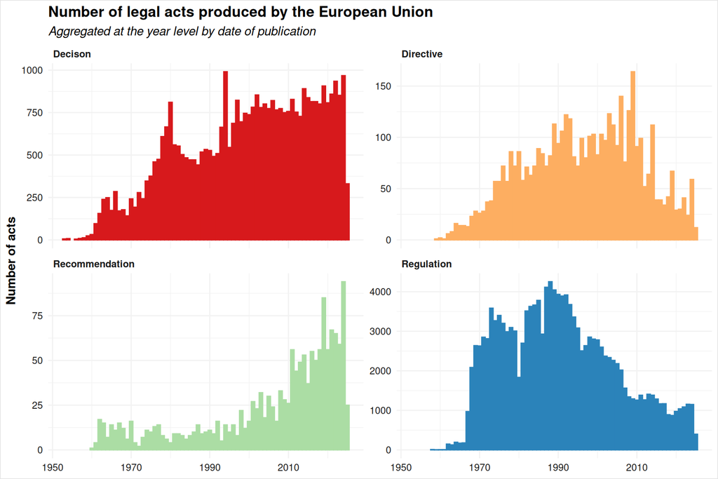

## 1.2 Dataframe

|  | year | type | n |
| --- | --- | --- | --- |
| 1 | 1953 | Decison | 6 |
| 2 | 1954 | Decison | 8 |
| 3 | 1956 | Decison | 5 |
| 4 | 1957 | Decison | 9 |
| 5 | 1958 | Decison | 13 |
| 6 | 1958 | Regulation | 10 |
| 7 | 1959 | Decison | 24 |
| 8 | 1959 | Directive | 1 |
| 9 | 1959 | Regulation | 4 |
| 10 | 1960 | Decison | 32 |

[output cut: 263 more lines]

## 1.3 Code: Data

```r
# packages
library(eurlex)
library(ggplot2)
library(dplyr)
library(purrr)
library(tidyr)
library(stringr)
library(rmarkdown)
library(modelsummary)
library(ggiraph)
library(equatiomatic)
library(DT)
library(gdtools)
library(gfonts)

# seed
set.seed(35239)

# fonts
register_gfont("Open Sans")
addGFontHtmlDependency(family = "Open Sans")

# current date
date_now <- Sys.Date()
date_now_f <- str_remove(format(date_now, "%d %B %Y"), "^0")
day_now <- as.integer(str_sub(date_now, 9, 10))
year_now <- as.integer(str_sub(date_now, 1, 4))

# acts
acts_proposals <- elx_make_query("any", sector = 3,
                                 include_date = TRUE,
                                 include_proposal = TRUE) |>
  elx_run_query() |>
  select(-work)

# acts only
acts <- acts_proposals |>
  filter(!is.na(celex),
         !date %in% c("1003-03-03")) |>
  distinct(celex, .keep_all = T) |>
  select(-proposal)

# in force
in_force <- elx_make_query("any", sector = 3,
                           include_force = TRUE,
                           include_date_force = TRUE) |>
  elx_run_query() |>
  select(-work) |>
  rename(date_force = dateforce) |>
  arrange(celex, date_force) |>
  distinct(celex, .keep_all = TRUE) |>
  drop_na() |>
  filter(between(as.Date(date_force), as.Date("1952-01-01"),
                 as.Date(date_now)))

# 4 main types of acts
regs <- acts |> filter(str_sub(celex,6,6) == "R")
decs <- acts |> filter(str_sub(celex,6,6) == "D")
dirs <- acts |> filter(str_sub(celex,6,6) == "L")
recs <- acts |> filter(str_sub(celex,6,6) == "H")

# proposals
proposals <- elx_make_query("proposal", include_date = TRUE) |>
  elx_run_query() |>
  select(-work,-type) |>
  rename(date_proposal = date) |>
  filter(!is.na(celex),
         !is.na(date_proposal)) |>
  distinct(celex, .keep_all = TRUE)

# latest act titles and EuroVoc
recent_titles <- acts |>
  arrange(desc(date), desc(celex)) |>
  filter(str_sub(celex,6,6) %in% c("D","R","L","H")) |>
  slice(1:50) |>
  mutate(title = map_chr(str_c("http://publications.europa.eu/resource/celex/",
                               celex),
                         possibly(eurlex::elx_fetch_data, otherwise = NA_character_), "title")) |>
  mutate(date = as.Date(date))

# citation
cit_page <- paste("Michal Ovádek, '",rmarkdown::metadata$title,"', available at https://michalovadek.github.io/eulaw/, accessed on ", date_now_f,
                  sep = "")
```

## 1.4 Code: Plot

```r
# select only main act types
relevant_acts <- bind_rows(Regulation = regs, Decison = decs, Directive = dirs,
                           Recommendation = recs,
                        .id = "type") |>
  mutate(year = as.integer(str_sub(celex, 2,5))) |>
  mutate(month_year = as.Date(str_replace(date, "[:digit:][:digit:]$", "01")))

# count
n_relevant <- relevant_acts |>
  count(year, type)

# viz
ggplot(n_relevant, aes(x = year, y = n, fill = type, color = type)) +
  geom_col(show.legend = FALSE) +
  scale_fill_brewer(palette = "Spectral") +
  scale_color_brewer(palette = "Spectral") +
  facet_wrap(~type, scale = "free_y") +
  theme_minimal() +
  theme(legend.position = "top",
        legend.justification = "left",
        legend.title = element_text(face = "italic"),
        plot.background = element_rect(fill = "white", color = "grey88"),
        panel.grid = element_line(color = "grey95"),
        axis.text = element_text(color = "grey10"),
        title = element_text(face = "bold"),
        plot.subtitle = element_text(face = "italic"),
        strip.text = element_text(hjust = 0, face = "bold")) +
  labs(x = NULL,
       y = "Number of acts",
       title = "Number of legal acts produced by the European Union",
       subtitle = "Aggregated at the year level by date of publication")

# vars for text
year1 <- as.integer(str_sub(date_now,1,4))-1
year2 <- as.integer(str_sub(date_now,1,4))-2

n_year1 <- n_relevant |>
  filter(year == year1) |>
  summarise(n = sum(n, na.rm = T)) |>
  as.integer()

n_year2 <- n_relevant |>
  filter(year == year2) |>
  summarise(n = sum(n, na.rm = T)) |>
  as.integer()

nyeardif <- ifelse(n_year1 < n_year2, "less than", "more than")
nyeardif <- ifelse(n_year1 == n_year2, "the same as", nyeardif)
```

In `2024`, the EU produced `2270` legal acts which is `more than` the `2090` acts in `2023`. Overall, the EU’s legislative output is currently considerably lower compared to, in particular, the 1980s and 1990s.

# 2 Proportion of act types

So we see there is significant over-time variation in the use of the different types of legal acts, but some types of acts, notably regulations, have been historically significantly more common than other types of acts. We can visualize the evolution of proportions directly.

## 2.1 Plot

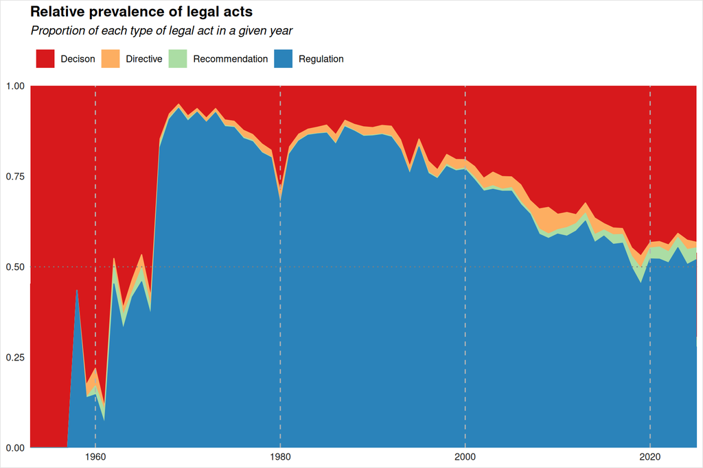

## 2.2 Code

```r
# create df
proptime_df <- expand.grid(year = min(n_relevant$year):max(n_relevant$year),
            type = unique(n_relevant$type)) |>
  left_join(n_relevant) |>
  mutate(n = ifelse(is.na(n), 0L, n)) |>
  group_by(year) |>
  mutate(total_y = sum(n),
         proportion = n/total_y) |>
  ungroup()

# viz
proptime_df |>
  ggplot(aes(x = year, y = proportion, fill = type, color = type)) +
  geom_area(show.legend = TRUE) +
  geom_vline(xintercept = c(1960,1980,2000,2020), lty = 2, color = "grey70") +
  geom_hline(yintercept = 0.50, color = "grey50", lty = 3) +
  scale_fill_brewer(palette = "Spectral") +
  scale_color_brewer(palette = "Spectral") +
  theme_minimal() +
  theme(legend.position = "top",
        legend.justification = "left",
        legend.title = element_text(face = "italic"),
        plot.background = element_rect(fill = "white", color = "grey88"),
        panel.grid = element_blank(),
        axis.text = element_text(color = "grey10"),
        title = element_text(face = "bold"),
        plot.subtitle = element_text(face = "italic"),
        strip.text = element_text(hjust = 0, face = "bold")) +
  scale_x_continuous(expand = c(0,0)) +
  scale_y_continuous(expand = c(0,0)) +
  labs(x = NULL,
       y = NULL,
       color = NULL,
       fill = NULL,
       title = "Relative prevalence of legal acts",
       subtitle = "Proportion of each type of legal act in a given year")
```

## 2.3 Dataframe

|  | year | type | n | total_y | proportion |
| --- | --- | --- | --- | --- | --- |
| 1 | 1953 | Decison | 6 | 6 | 1 |
| 2 | 1954 | Decison | 8 | 8 | 1 |
| 3 | 1955 | Decison | 0 | 0 |  |
| 4 | 1956 | Decison | 5 | 5 | 1 |
| 5 | 1957 | Decison | 9 | 9 | 1 |
| 6 | 1958 | Decison | 13 | 23 | 0.5652173913043478 |
| 7 | 1959 | Decison | 24 | 29 | 0.8275862068965517 |
| 8 | 1960 | Decison | 32 | 41 | 0.7804878048780488 |
| 9 | 1961 | Decison | 96 | 108 | 0.8888888888888888 |
| 10 | 1962 | Decison | 156 | 327 | 0.4770642201834863 |

[output cut: 282 more lines]

We can see that although regulations used to dominate the EU’s legislative output, decisions – which are typically associated with various administrative actions – are nowadays almost equally prevalent.

The rise in the number of recommendations can be mostly attributed to the strengthening of the EU’s role in the surveillance and coordination of the Member States’ economic policies.

# 3 Year-on-year comparison

The daily streaming of data can be relied on to make completely up-to-date comparisons of EU legislative activity. For example, we can look at the extent to which the monthly adoption rate of legal acts this year differs from last year.

## 3.1 Plot

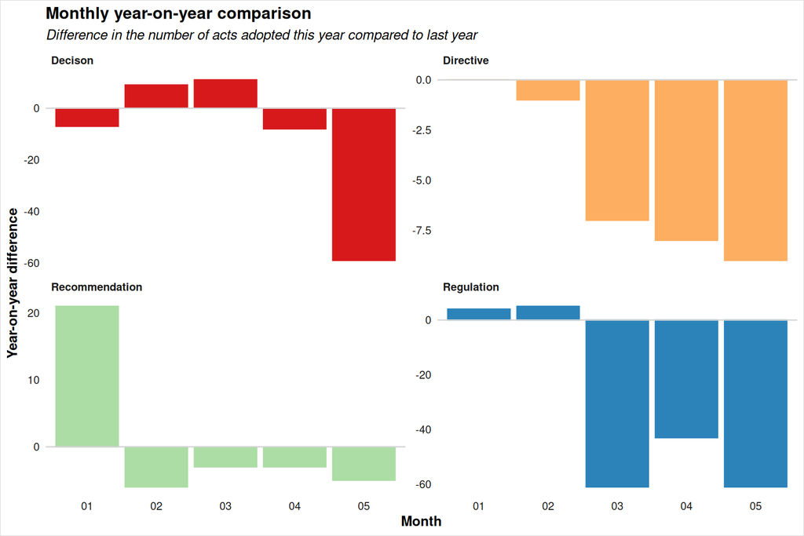

## 3.2 Code

```r
# monthly output last two years
last_two_years <- relevant_acts |>
  mutate(year = as.integer(str_sub(date, 1,4))) |>
  filter(year %in% c(max(relevant_acts$year), max(relevant_acts$year)-1)) |>
  count(month_year, type)

last_two_years_full <- expand.grid(month_year = unique(last_two_years$month_year),
                                   type = unique(last_two_years$type)) |>
  left_join(last_two_years) |>
  mutate(n = ifelse(is.na(n), 0L, n))

# year on year change
last_two_yoy_diff <- last_two_years_full |>
  arrange(month_year) |>
  mutate(month = str_sub(month_year, 6,7)) |>
  group_by(month, type) |>
  reframe(yoy_diff = diff(n))

# this month for text
this_month_yoy <- last_two_yoy_diff |>
  arrange(desc(month)) |>
  slice(1:4) |>
  summarise(sum = sum(yoy_diff)) |>
  as.integer()

this_month_yoy_dir <- ifelse(this_month_yoy < 0, "fewer than", "more than")
#this_month_yoy_dir <- ifelse(this_month_yoy == 0, "the same as", this_month_yoy)

this_month_yoy_abs <- abs(this_month_yoy)

# viz
last_two_yoy_diff |>
  ggplot(aes(x = month, y = yoy_diff, fill = type, color = type)) +
  geom_col(show.legend = FALSE) +
  geom_hline(yintercept = 0, color = "grey83", lty = 1) +
  facet_wrap(~type, scales = "free_y") +
  scale_fill_brewer(palette = "Spectral") +
  scale_color_brewer(palette = "Spectral") +
  theme_minimal() +
  theme(legend.position = "top",
        legend.justification = "left",
        legend.title = element_text(face = "italic"),
        plot.background = element_rect(fill = "white", color = "grey88"),
        panel.grid = element_blank(),
        axis.text = element_text(color = "grey10"),
        title = element_text(face = "bold"),
        plot.subtitle = element_text(face = "italic"),
        strip.text = element_text(hjust = 0, face = "bold")) +
  labs(x = "Month", y = "Year-on-year difference",
       title = "Monthly year-on-year comparison",
       subtitle = "Difference in the number of acts adopted this year compared to last year")
```

## 3.3 Dataframe

|  | month | type | yoy_diff |
| --- | --- | --- | --- |
| 1 | 01 | Decison | -7 |
| 2 | 01 | Directive | 0 |
| 3 | 01 | Recommendation | 21 |
| 4 | 01 | Regulation | 4 |
| 5 | 02 | Decison | 9 |
| 6 | 02 | Directive | -1 |
| 7 | 02 | Recommendation | -6 |
| 8 | 02 | Regulation | 5 |
| 9 | 03 | Decison | 11 |
| 10 | 03 | Directive | -7 |

[output cut: 10 more lines]

So far this month, the EU has adopted `134` legal acts `fewer than` the same month last year.

# 4 Acts in force

Naturally, not all legal acts remain in force indefinitely, which means that many of the `205480` acts ever adopted by the EU are mere relics of the past.

According to Eur-Lex, the EU has `43305` legal acts in force at the moment, though a closer examination shows that many of those acts are practically obsolete, even if technically still valid. For example, act `31952S0004` is considered in force, but its sole purpose was to set the period for the collection of coal and steel levies in 1953.

Despite this data caveat, it is still interesting to find out how long ago the acts that are currently applicable have entered into force.

## 4.1 Plot

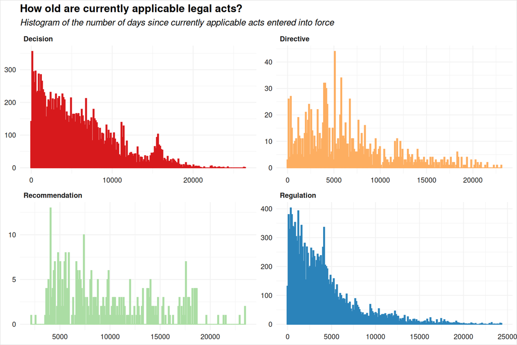

## 4.2 Code

```r
# viz
in_force |>
  filter(force == "true") |>
  mutate(days_in_force = as.integer(as.Date(Sys.Date()) - as.Date(date_force)),
         type = str_sub(celex, 6,6)) |>
  filter(type %in% c("R","L","H","D")) |>
  mutate(type = case_when(type == "D" ~ "Decision",
                          type == "H" ~ "Recommendation",
                          type == "L" ~ "Directive",
                          type == "R" ~ "Regulation",
                          T ~ NA_character_)) |>
  mutate(months_in_force = days_in_force/12) |>
  ggplot(aes(x = days_in_force, fill = type, color = type)) +
  geom_histogram(bins = 200, show.legend = FALSE) +
  scale_fill_brewer(palette = "Spectral") +
  scale_color_brewer(palette = "Spectral") +
  theme_minimal() +
  theme(legend.position = "top",
        legend.justification = "left",
        legend.title = element_text(face = "italic"),
        plot.background = element_rect(fill = "white", color = "grey88"),
        panel.grid = element_line(color = "grey95"),
        axis.text = element_text(color = "grey10"),
        title = element_text(face = "bold"),
        plot.subtitle = element_text(face = "italic"),
        strip.text = element_text(hjust = 0, face = "bold")) +
  facet_wrap(~type, scales = "free") +
  labs(x = NULL,
       y = NULL,
       color = NULL,
       fill = NULL,
       title = "How old are currently applicable legal acts?",
       subtitle = "Histogram of the number of days since currently applicable acts entered into force")
```

## 4.3 Dataframe

|  | celex | date_force | force |
| --- | --- | --- | --- |
| 1 | 31952S0002 | 1953-01-01 | false |
| 2 | 31952S0003 | 1953-01-01 | false |
| 3 | 31952S0004 | 1953-01-01 | true |
| 4 | 31953D0004 | 1953-02-12 | false |
| 5 | 31953D0030 | 1953-05-04 | true |
| 6 | 31953D0031 | 1953-05-04 | false |
| 7 | 31953D0032 | 1953-05-21 | false |
| 8 | 31953D0038 | 1953-07-21 | true |
| 9 | 31953D0210(06) | 1953-01-16 | true |
| 10 | 31953S0028 | 1953-03-15 | false |

[output cut: 990 more lines]

We see that the bulk of the currently legally applicable acts have been adopted relatively recently.

# 5 Legislative efficiency

The image of the EU as an unwieldy bureaucracy with a complicated legislative system appears often in national media. Moreover, most theoretical literature on political systems would expect the number of veto players to affect legislative efficiency. On this basis, we formulate the simple hypothesis that

> H1: The more EU Member States there are, the longer it takes to pass legislation.

Most people are therefore susceptible to assume that the EU needs a lot of time to adopt legal acts. Let’s use Eur-Lex data to find out just how long it normally takes to pass legislation.

## 5.1 Plot

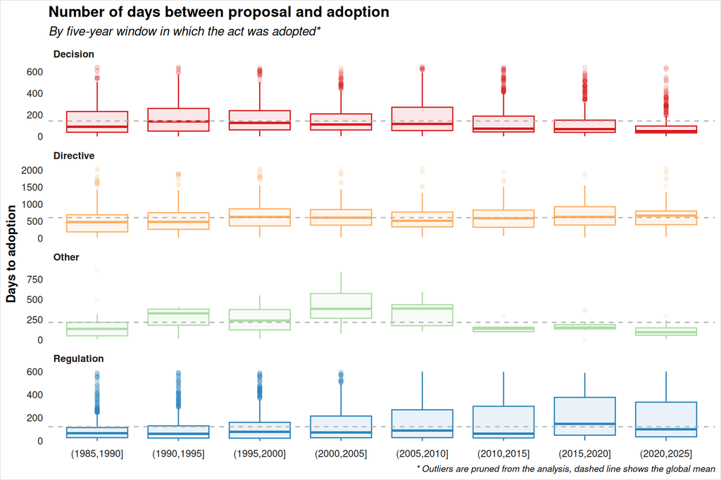

## 5.2 Code

```r
# calculate maximum length of adoption and discard negative
acts_days <- acts_proposals |>
  filter(!is.na(celex),
         !is.na(date),
         !is.na(proposal)) |>
  left_join(proposals, by = c("proposal"="celex")) |>
  mutate(days = as.integer(as.Date(date) - as.Date(date_proposal))) |>
  filter(days > -1) |>
  group_by(celex) |>
  filter(days == max(days)) |>
  ungroup() |>
  distinct(celex, .keep_all = TRUE) |>
  arrange(date) |>
  mutate(year_adopted = as.integer(str_sub(date, 1, 4)),
         type = str_sub(celex, 6, 6),
         type = case_when(type == "R" ~ "Regulation",
                          type == "L" ~ "Directive",
                          type == "D" ~ "Decision",
                          T ~ "Other"),
         five_year = cut_interval(year_adopted, length = 5)) |>
  filter(year_adopted > 1985) # not many complete pairs before this

# identify outliers
outliers <- acts_days |>
  group_by(type) |>
  mutate(max = max(days),
         mean = mean(days),
         coef = days / mean) |>
  filter(coef > 2.9) |>
  ungroup()

# plot
acts_days |>
  filter(!celex %in% outliers$celex) |>
  group_by(type) |>
  mutate(global_mean = mean(days)) |>
  ggplot(aes(x = five_year, y = days, color = type, fill = type)) +
  geom_boxplot(alpha = 0.1, show.legend = FALSE) +
  geom_hline(aes(yintercept = global_mean), lty = 2, color = "grey70") +
  facet_wrap(~type, dir = "h", ncol = 1, scales = "free_y") +
  scale_fill_brewer(palette = "Spectral") +
  scale_color_brewer(palette = "Spectral") +
  theme_minimal() +
  theme(legend.position = "top",
        legend.justification = "left",
        legend.title = element_text(face = "italic"),
        plot.background = element_rect(fill = "white", color = "grey88"),
        panel.grid = element_blank(),
        axis.text = element_text(color = "grey10"),
        title = element_text(face = "bold"),
        plot.subtitle = element_text(face = "italic"),
        plot.caption = element_text(face = "italic", size = 8),
        strip.text = element_text(hjust = 0, face = "bold")) +
  labs(x = NULL,
       y = "Days to adoption",
       title = "Number of days between proposal and adoption",
       subtitle = "By five-year window in which the act was adopted*",
       caption = "* Outliers are pruned from the analysis, dashed line shows the global mean")
```

## 5.3 Dataframe

|  | celex | date | proposal | date_proposal | days | year_adopted | type | five_year |
| --- | --- | --- | --- | --- | --- | --- | --- | --- |
| 1 | 31986R0060 | 1986-01-07 | 51985PC0765(01) | 1985-12-18 | 20 | 1986 | Regulation | (1985,1990] |
| 2 | 31986R0139 | 1986-01-20 | 51984PC0227 | 1984-06-12 | 587 | 1986 | Regulation | (1985,1990] |
| 3 | 31986D0008 | 1986-01-20 | 51985PC0781 | 1985-12-16 | 35 | 1986 | Decision | (1985,1990] |
| 4 | 31986D0006 | 1986-01-20 | 51985PC0374 | 1985-07-15 | 189 | 1986 | Decision | (1985,1990] |
| 5 | 31986D0005 | 1986-01-20 | 51985PC0354 | 1985-07-05 | 199 | 1986 | Decision | (1985,1990] |
| 6 | 31986R0113 | 1986-01-20 | 51985PC0852 | 1986-01-08 | 12 | 1986 | Regulation | (1985,1990] |
| 7 | 31986R0112 | 1986-01-20 | 51985PC0847 | 1986-01-08 | 12 | 1986 | Regulation | (1985,1990] |
| 8 | 31986R0232 | 1986-01-27 | 51985PC0482 | 1985-09-17 | 132 | 1986 | Regulation | (1985,1990] |
| 9 | 31986D0019 | 1986-01-27 | 51985PC0663 | 1985-11-27 | 61 | 1986 | Decision | (1985,1990] |
| 10 | 31986R0231 | 1986-01-27 | 51985PC0783 | 1985-12-16 | 42 | 1986 | Regulation | (1985,1990] |

[output cut: 990 more lines]

Directives take by far the longest to adopt; unlike decisions and regulations, they are rarely deployed to regulate trivial matters. Nonetheless, there are few easily discernible temporal patterns in the plot. Most of all, it is not obvious that legislative efficiency would decrease as the EU expanded its membership.

However, before moving onto further investigation of the efficiency hypothesis, we should pause and take a look at some of the discarded outliers. What legislation took the longest to adopt?

[interactive chart not shown]

It turns out that many of the slowest legislative processes concerned – and this is particularly visible recently – the conclusion of international agreements. In these situations, the speed does not depend solely on the EU, as an agreement can only be formally concluded once the legal text is successfully negotiated with a third party.

Most acts on the list of slowest legislative files took well over ten years to complete.

## 5.4 Regression

Regression analysis unpacks the relationship between a response (dependent) variable and one or more explanatory variables. In our case, we are interested in the relationship (or absence thereof) between the number of days it takes the EU to turn a Commission proposal into law and the number of Member States.

We will assume the relationship between the variables is functionally linear. Canonically, the linear model can be written as:

$$Y \sim \beta_0 + X\beta_1 + \epsilon$$

$$\epsilon \sim N(0,\sigma^2)$$

where $Y$ is the response variable, $X$ the explanatory variable, $\beta_0$ and $\beta_1$ the unknown parameters of the model and $\epsilon$ the error term which comes from a normal distribution with mean zero.

### 5.4.1 Table

|  | Baseline | Controls | Zero Intercept |
| --- | --- | --- | --- |
| Number of Member States | 5.742*** | 6.928*** | 6.928*** |
|  | (0.518) | (0.509) | (0.509) |
| Constant | 163.364*** |  |  |
|  | (10.590) |  |  |
| Act type = Other |  | 158.464*** | 158.464*** |
|  |  | (34.011) | (34.011) |
| Act type = Regulation |  | -70.960* | 87.504*** |
|  |  | (32.566) | (9.963) |
| Act type = Decision |  | -88.325** | 70.139*** |
|  |  | (32.629) | (12.548) |
| Act type = Directive |  | 420.837*** | 579.301*** |
|  |  | (33.603) | (13.478) |
| Num.Obs. | 14930 | 14930 | 14930 |
| R2 | 0.008 | 0.144 | 0.384 |
| R2 Adj. | 0.008 | 0.144 | 0.384 |
| AIC | 223876.7 | 221685.6 | 221685.6 |
| BIC | 223899.5 | 221731.3 | 221731.3 |
| Log.Lik. | -111935.341 | -110836.798 | -110836.798 |
| RMSE | 436.33 | 405.38 | 405.38 |

+ p < 0.1, * p < 0.05, ** p < 0.01, *** p < 0.001  
In the 'Controls' specification, 'Other' is the reference category.

### 5.4.2 Equation

Plugging in the variables and estimated coefficients, the following regression equation predicts the number of days an act would take to pass given some combination of input values:

$$\operatorname{\widehat{days}} = 158.46() + 6.93(\operatorname{n\_ms}) -
88.32(\operatorname{type}_{\operatorname{Decision}}) +
420.84(\operatorname{type}_{\operatorname{Directive}}) -
70.96(\operatorname{type}_{\operatorname{Regulation}})$$

### 5.4.3 Plot

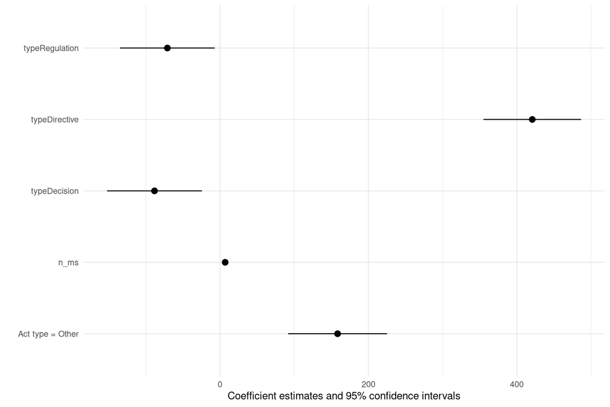

### 5.4.4 Code

```r
# number of member states over time
ms_years <- bind_rows(
  data.frame(
    year = 1952:1972,
    n_ms = 6
  ),
  data.frame(
    year = 1973:1980,
    n_ms = 9
  ),
  data.frame(
    year = 1981:1985,
    n_ms = 10
  ),
  data.frame(
    year = 1986:1994,
    n_ms = 12
  ),
  data.frame(
    year = 1995:2004,
    n_ms = 15
  ),
  data.frame(
    year = 2005:2006,
    n_ms = 25
  ),
  data.frame(
    year = 2007:2013,
    n_ms = 27
  ),
  data.frame(
    year = 2014:2018,
    n_ms = 28
  ),
  data.frame(
    year = 2019:2025,
    n_ms = 27
  )
)

# append N member states
days_ms <- acts_days |>
  left_join(ms_years, by = c("year_adopted"="year")) |>
  mutate(type = relevel(as.factor(type), ref = "Other"))

# regress
models <- list()

## m0
models[['Baseline']] <- lm(
  data = days_ms,
  formula = days ~ n_ms
)
names(models[['Baseline']]$coefficients)[1] <- "Constant"

## m1
models[['Controls']] <- lm(
  data = days_ms,
  formula = days ~ n_ms + type
)
names(models[['Controls']]$coefficients)[1] <- "Act type = Other"

## m2
models[['Zero Intercept']] <- lm(
  data = days_ms,
  formula = days ~ n_ms + type + 0
)

# effect size
effect <- as.numeric(round(models[['Controls']]$coefficients[which(names(models[['Controls']]$coefficients) == "n_ms")],2))

# summary for p values
mod_sum <- summary(models[['Controls']])

# p value
p_value <- mod_sum$coefficient[names(mod_sum$coefficient[,1]) == "n_ms", 4]

# p threshold
p_thresh <- 0.05

# can we reject the null
reject_null <- ifelse(effect > 0 & p_value < p_thresh, "can reject", "cannot reject")

# show table
modelsummary(models,
             stars = TRUE,
             coef_map = c("n_ms" = "Number of Member States",
                          "Constant" = "Constant",
                          "typeOther" = "Act type = Other",
                          "Act type = Other" = "Act type = Other",
                          "typeRegulation" = "Act type = Regulation",
                          "typeDecision" = "Act type = Decision",
                          "typeDirective" = "Act type = Directive"),
             title = "Linear regression model of legislative efficiency (Y_i = days)",
             notes = list("In the 'Controls' specification, 'Other' is the reference category."))
```

### 5.4.5 Dataframe

|  | celex | date | proposal | date_proposal | days | year_adopted | type | five_year | n_ms |
| --- | --- | --- | --- | --- | --- | --- | --- | --- | --- |
| 1 | 31986R0060 | 1986-01-07 | 51985PC0765(01) | 1985-12-18 | 20 | 1986 | Regulation | (1985,1990] | 12 |
| 2 | 31986R0139 | 1986-01-20 | 51984PC0227 | 1984-06-12 | 587 | 1986 | Regulation | (1985,1990] | 12 |
| 3 | 31986D0008 | 1986-01-20 | 51985PC0781 | 1985-12-16 | 35 | 1986 | Decision | (1985,1990] | 12 |
| 4 | 31986D0006 | 1986-01-20 | 51985PC0374 | 1985-07-15 | 189 | 1986 | Decision | (1985,1990] | 12 |
| 5 | 31986D0005 | 1986-01-20 | 51985PC0354 | 1985-07-05 | 199 | 1986 | Decision | (1985,1990] | 12 |
| 6 | 31986R0113 | 1986-01-20 | 51985PC0852 | 1986-01-08 | 12 | 1986 | Regulation | (1985,1990] | 12 |
| 7 | 31986R0112 | 1986-01-20 | 51985PC0847 | 1986-01-08 | 12 | 1986 | Regulation | (1985,1990] | 12 |
| 8 | 31986R0232 | 1986-01-27 | 51985PC0482 | 1985-09-17 | 132 | 1986 | Regulation | (1985,1990] | 12 |
| 9 | 31986D0019 | 1986-01-27 | 51985PC0663 | 1985-11-27 | 61 | 1986 | Decision | (1985,1990] | 12 |
| 10 | 31986R0231 | 1986-01-27 | 51985PC0783 | 1985-12-16 | 42 | 1986 | Regulation | (1985,1990] | 12 |

[output cut: 990 more lines]

Controlling for the type of act, the linear model predicts that for every additional Member State, the EU takes on average `6.93` days longer to adopt the legal act. This effect is `statistically significant` at `0.05` alpha.

This model is far too simple to establish the existence of a causal relationship between the number of Member States and legislative efficiency. Indeed, some scholars would argue that no amount of conditioning on observables is sufficient to establish causality. Moreover, Poisson regression would be more appropriate here as our dependent variable is discrete and bounded at zero.

Nonetheless, our simple analysis suggests that we `can reject` the null hypothesis that more Member States in the EU system are not associated with slower law-making.

# 6 Legal bases

Each legal act of the EU needs to have a *legal basis* in the EU Treaties or in a pre-existing EU law in case of delegated and implementing acts. This is known as the [principle of conferral](https://en.wikipedia.org/wiki/Principle_of_conferral) and essentially represents the EU equivalent of the concept of enumerated powers in the United States.

Data on legal bases can help us better understand the EU legislative output.

The most common legal basis historically is Council Regulation (EC) No 139/2004 of 20 January 2004 on the control of concentrations between undertakings (the EC Merger Regulation). It has been used as a legal basis on `6697` occasions and it is a non-treaty legal basis. The prevalence of this particular piece of legislation underscores the EU’s regulatory role in trying to ensure a competitive playing field in the single market. It is still in force.

Nonetheless, when we think of legal bases, we usually imagine a Treaty competence. Looking exclusively at legal bases in the Treaty on the Functioning of the European Union (TFEU) and Treaty on European Union (TEU), the following table let’s you browse the most invoked competences since the entry into force of the Treaty of Lisbon.

|  | lb_name | n_invoked | lb_celex | art_num | art_treaty |
| --- | --- | --- | --- | --- | --- |
| 1 | Article 218 TFEU | 2039 | 12008E218 | 218 | TFEU |
| 2 | Article 319 TFEU | 1440 | 12008E319 | 319 | TFEU |
| 3 | Article 29 TEU | 838 | 12008M029 | 29 | TEU |
| 4 | Article 207 TFEU | 802 | 12008E207 | 207 | TFEU |
| 5 | Article 31 TEU | 612 | 12008M031 | 31 | TEU |
| 6 | Article 305 TFEU | 524 | 12008E305 | 305 | TFEU |
| 7 | Article 43 TFEU | 514 | 12008E043 | 43 | TFEU |
| 8 | Article 114 TFEU | 478 | 12008E114 | 114 | TFEU |
| 9 | Article 294 TFEU | 470 | 12008E294 | 294 | TFEU |
| 10 | Article 28 TEU | 441 | 12008M028 | 28 | TEU |

[output cut: 211 more lines]

The focus on Treaty competences should not, however, obscure the fact that many EU acts are based on existing legislation rather than directly on a Treaty legal basis.

## 6.1 Plot

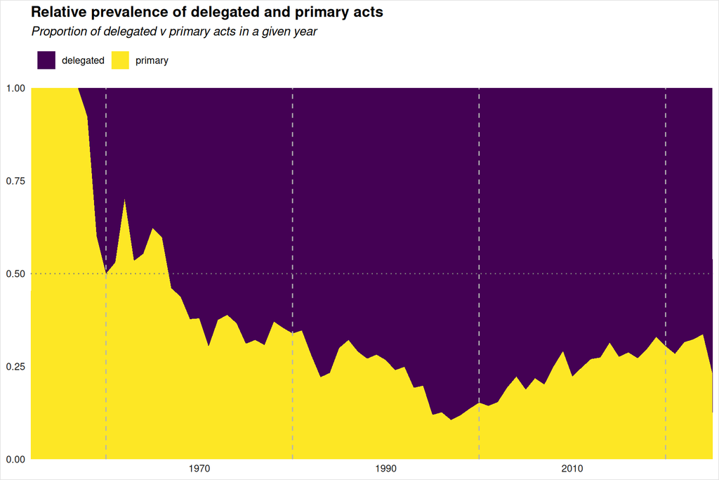

## 6.2 Dataframe

|  | act_year | delegated | n | prop |
| --- | --- | --- | --- | --- |
| 1 | 1952 | delegated | 0 | 0 |
| 2 | 1952 | primary | 3 | 1 |
| 3 | 1953 | delegated | 0 | 0 |
| 4 | 1953 | primary | 10 | 1 |
| 5 | 1954 | delegated | 0 | 0 |
| 6 | 1954 | primary | 14 | 1 |
| 7 | 1955 | delegated | 0 | 0 |
| 8 | 1955 | primary | 6 | 1 |
| 9 | 1956 | delegated | 0 | 0 |
| 10 | 1956 | primary | 12 | 1 |

[output cut: 138 more lines]

## 6.3 Code: Data

```r
# get legal basis data
lbs <- elx_make_query("any", sector = 3, include_lbs = TRUE) |>
  elx_run_query() |>
  select(-work, -lbs) |>
  filter(!is.na(celex), !is.na(lbcelex))

# select only EU treaties-based acts
acts_treaty <- lbs |>
  filter(str_detect(lbcelex, "^1.*([:digit:]|[:punct:])$")) |>
  distinct(celex)

# lbs enriched
lbs_enriched <- lbs |>
  mutate(delegated = ifelse(celex %in% acts_treaty$celex, "primary", "delegated")) |>
  mutate(lbcelex = str_replace(lbcelex, "^1201[:digit:](?=[E|M])", "12008"),
         lbcelex = str_replace(lbcelex, "^12006(?=[E|M])", "12002")) |>
  mutate(act_year = as.integer(str_sub(celex, 2,5)),
         act_type = str_sub(celex, 6,6),
         lb_year = as.integer(str_sub(lbcelex, 2,5)),
         lb_treaty = str_detect(lbcelex, "^1[:digit:]{4}[:upper:][:digit:]{3,}"),
         lb_type = paste(str_sub(lbcelex,1,1), str_sub(lbcelex,6,6), sep = "_"),
         dist_year_lb = act_year - lb_year) |>
  filter(!str_detect(lbcelex, "^1.*[:upper:]$"))

# most common lbs
most_common_lbs <- lbs_enriched |>
  distinct(celex, lbcelex, .keep_all = TRUE) |>
  count(lbcelex) |>
  arrange(-n)

# titles of most common lbs
most_common_lbs10 <- most_common_lbs |>
  slice(1:10) |>
  mutate(title = map_chr(paste("http://publications.europa.eu/resource/celex/", lbcelex, sep = ""), possibly(eurlex::elx_fetch_data, otherwise = NA_character_), "title"),
         title = str_squish(str_remove(title, "\\(?Text with EEA relevance\\)?")))

# most common lisbon lbs
lisbon_lbs_n <- most_common_lbs |>
  filter(str_detect(lbcelex, "^12008[E|M][:digit:]")) |>
  mutate(art_num = as.integer(str_extract(lbcelex, "(?<=E|M)[:digit:]+")),
         art_treaty = ifelse(str_detect(lbcelex, "8E"), "TFEU", "TEU"),
         lb_name = str_c("Article ", art_num, " ", art_treaty)) |>
  rename(lb_celex = lbcelex,
         n_invoked = n) |>
  relocate(lb_name, n_invoked, .before = 1)
```

## 6.4 Code: Plot

```r
# df delegated v primary over time
deleg_prop_time <- lbs_enriched |>
  distinct(celex, .keep_all = TRUE) |>
  count(act_year, delegated) |>
  complete(act_year, delegated, fill = list(n = 0L)) |>
  group_by(act_year) |>
  mutate(prop = n/sum(n)) |>
  ungroup()

# vars for text
deleg_last_y <- deleg_prop_time |> filter(act_year==year1, delegated == "delegated")

# viz delegated over time
deleg_prop_time |>
  ggplot(aes(x = act_year, y = prop, fill = delegated)) +
  geom_area(show.legend = TRUE) +
  geom_vline(xintercept = c(1960,1980,2000,2020), lty = 2, color = "grey70") +
  geom_hline(yintercept = 0.50, color = "grey50", lty = 3) +
  scale_fill_viridis_d() +
  scale_color_viridis_d() +
  theme_minimal() +
  theme(legend.position = "top",
        legend.justification = "left",
        legend.title = element_text(face = "italic"),
        plot.background = element_rect(fill = "white", color = "grey88"),
        panel.grid = element_blank(),
        axis.text = element_text(color = "grey10"),
        title = element_text(face = "bold"),
        plot.subtitle = element_text(face = "italic"),
        strip.text = element_text(hjust = 0, face = "bold")) +
  scale_x_continuous(expand = c(0,0)) +
  scale_y_continuous(expand = c(0,0)) +
  labs(x = NULL,
       y = NULL,
       color = NULL,
       fill = NULL,
       title = "Relative prevalence of delegated and primary acts",
       subtitle = "Proportion of delegated v primary acts in a given year")
```

It turns out that most legal acts adopted by the EU have been delegated (and implementing) acts, that is acts based on another piece of legislation rather than one of the EU Treaties (primary acts). Last year, such *delegated* acts represented `66` per cent of the EU’s yearly legislative output.

# 7 Cite

Cite this document as Michal Ovádek, ‘Legislative Output of the European Union’, available at https://michalovadek.github.io/eulaw/, accessed on 19 May 2025.

[^1]: See https://github.com/michalovadek/eurlex for more details.
[^2]: This also means that any omissions and mistakes present in Eur-Lex are carried through to the output shown here.
[^3]: We should also take into account the regulatory breadth and depth of each legal act. A decision increasing the tariff on steel by 5 per cent is a very different act from, say, the General Data Protection Regulation.